# Turismo de Naturaleza

Principales indicadores para caracterizar los viajes y el perfil de las y los viajeros, nacionales y extranjeros, que realizan Turismo de Naturaleza en Argentina.

# Presentación

El **turismo de naturaleza** o **turismo activo natural** -que incluye al turismo aventura, el ecoturismo y otras prácticas en las que la naturaleza ocupa un rol protagónico- es un segmento estratégico para el sector turístico de Argentina y uno de los de mayor crecimiento en nuestro país y el mundo. Este crecimiento refleja una tendencia global en la que los destinos naturales, los espacios abiertos y las experiencias genuinas en ámbitos silvestres, permiten a una población crecientemente urbana reconectar con la naturaleza y ocupan un lugar central en la preferencia de los viajeros. La pandemia de Covid 19 no hizo más que reafirmar esta tendencia.

Argentina cuenta con un patrimonio natural incomparable, que explica gran parte del flujo turístico interno y receptivo. Este movimiento es una fuente de empleo y desarrollo económico de gran relevancia para nuestro país, y uno de los principales motores productivos de numerosas economías regionales. En este sentido, se encuentra en marcha un programa integral de turismo de naturaleza llamado [La Ruta Natural](https://www.argentina.gob.ar/turismoydeportes/larutanatural), con el cual Argentina se propone desarrollar territorios y comunidades con respeto a los valores naturales y la autenticidad cultural, como así también promocionar viajes seguros y turismo sustentable a partir del turismo de naturaleza en todo el territorio nacional.

Es desde este marco que la [Dirección Nacional de Mercados y Estadística del Ministerio de Turismo y Deportes de la Nación](https://www.yvera.tur.ar/sinta/) elaboró [un informe](https://tableros.yvera.tur.ar/institucional/turismo-naturaleza/informe_tur_nat.pdf) cuyo principal objetivo es caracterizar cuantitativamente los **principales aspectos del Turismo de Naturaleza**. Para esto se recurrió a dos de las principales fuentes de información con la que se cuenta tanto para el turismo nacional como el internacional. En cuanto a la primera, la **Encuesta de Viajes y Turismo de los Hogares (EVyTH)** releva información sociodemográfica de los residentes en argentina y de las principales caraceterísticas de sus viajes. La segunda, la **Encuesta de Turismo Internacional (ETI)**, en donde se indaga sobre los principales aspectos de las y los viajeros residentes en el exterior.

### ¿Qué se entiende por Turismo de Naturaleza según la ETI y la EVyTH?

**Según la ETI, se pueden consideran las siguientes actividades:**

- Turismo aventura.
- Actividades de baja diﬁcultad en medios naturales.
- Visita a parques nacionales.
- Actividades en la nieve.

**Según la EVyTH, se consideran las siguientes actividades:**

- Visitaron espacios rurales como estancias, granjas, etc.
- Visitaron parques nacionales o provinciales, reservas, etc.
- Hicieron esquí, snowboard, u otro deporte de nieve.
- Realizaron deportes de aventura como mountain bike, montañismo, rafting, travesías, ala delta, etc.
- Otras actividades en espacios abiertos y naturales.

# Principales resultados

## TURISMO INTERNACIONAL

### PARTICIPACIÓN ANUAL DE LOS TURISTAS QUE REALIZARON TURISMO DE NATURALEZA DURANTE SU VISITA A LA ARGENTINA

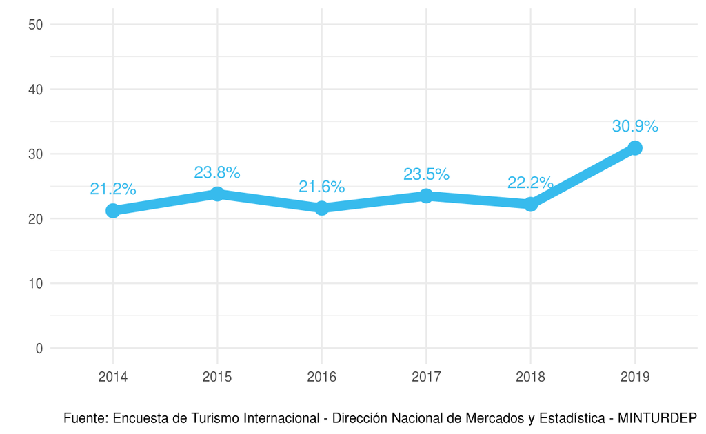

### PARTICIPACIÓN DE LOS/LAS TURISTAS QUE REALIZARON TURISMO DE NATURALEZA POR PAÍS DE RESIDENCIA. AÑO 2019

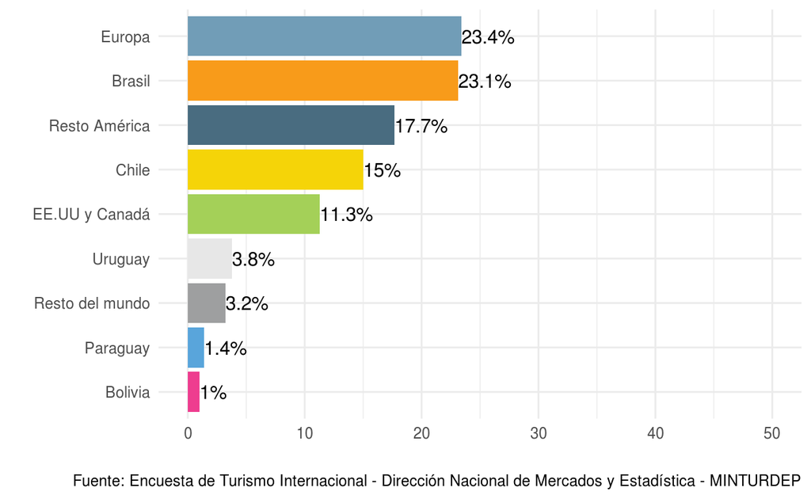

### ESTADÍA Y GASTO PROMEDIO

**PERFIL DEL TURISMO DE NATURALEZA - AÑO 2019**

Estadía y gasto promedio

| **Variable:** | **Total Turistas** | **Turistas de Naturaleza** |
| --- | --- | --- |
| Estadía promedio en la Argentina (en noches) | 12,0 | 14,2 |
| Gasto por turista (en US$) | 925,7 | 1.158,0 |
| Gasto promedio diario (en US$) | 77,3 | 81,5 |

**Fuente:** Dirección Nacional de Mercados y Estadística en base a la Encuesta de Turismo Internacional (ETI).

## TURISMO NACIONAL

### PARTICIPACIÓN ANUAL DE LOS TURISTAS QUE REALIZARON TURISMO DE NATURALEZA DURANTE SU VIAJE POR ARGENTINA

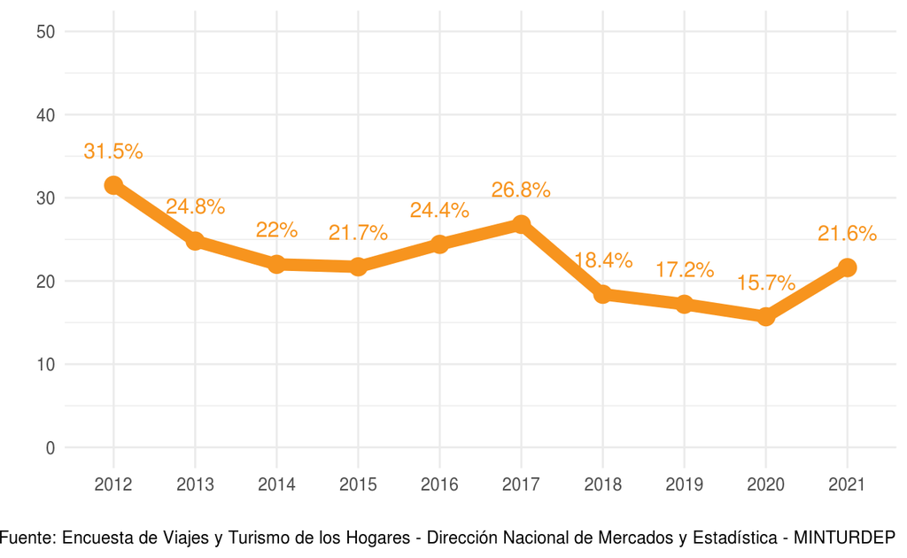

### PRINCIPALES REGIONES ELEGIDAS PARA REALIZAR TURISMO DE NATURALEZA. AÑO 2019

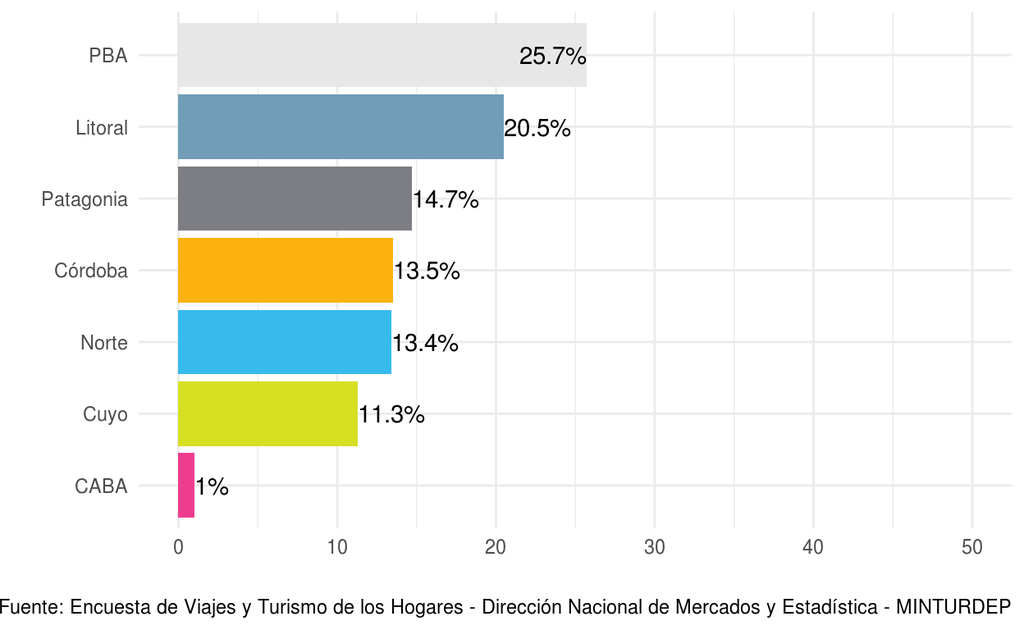

### ESTADÍA Y GASTO PROMEDIO*

**PERFIL DEL TURISMO DE NATURALEZA - AÑO 2019**

Estadía y gasto promedio

| **Variable:** | **Total Turistas** | **Turistas de Naturaleza** |
| --- | --- | --- |
| Estadía promedio en la Argentina (en noches) | 5,3 | 6,6 |
| Gasto por turista | 15.026,1 | 25.254,8 |
| Gasto promedio diario | 2.846,2 | 3.805,8 |

**Nota:** Gasto en pesos constantes a febrero de 2022 (IPC turístico).  
**Fuente:** Dirección Nacional de Mercados y Estadística en base a la Encuesta de Viajes y Turismo de los Hogares (EVyTH).